# YFI analyses

Nathan Byer (using data from J. A. Hillmer)

6/22/2022

# summarize the data

First, we will process the input dataset to facilitate downstream analysis. Basically, the code below reads in a cleaned version of the dataset (I removed any plots without post-treatment monitoring), removes rows if they have more than 20% missing data, summarize the number of plots with paired samples after this, and remove plots without paired samples. After doing so, we now have a neat and tidy 3 x 2 experimental design (3 treatments and 2 survey periods). In terms of sample sizes, things are a bit unbalanced, with 8 cut and herbicide, 17 cut and tarp, and 13 no treatment plots. This is not necessarily a problem - our models should be able to accommodate this with Type II or III sums of squares. Since we would expect there to be an interaction between our two main effects (after all, our treatments should be pretty noticeably different pre vs. post!), we should use Type III.

```r
YFIdata<-read.csv("YFIdata_cleaned.csv",header=T)
YFIdata_NAomit<-YFIdata[!(rowSums(is.na(YFIdata)) > ncol(YFIdata)*.2),]
n_occur <- data.frame(table(YFIdata_NAomit$plot_number_tag_number))
n_occur_2<-n_occur[n_occur$Freq==2,]
YFIdata_NAomit_onlypaired<-YFIdata_NAomit[YFIdata_NAomit$plot_number_tag_number %in% n_occur_2$Var1,]
YFIdata_NAomit_onlypaired$treatment_type<-factor(YFIdata_NAomit_onlypaired$treatment_type,levels = c("No treatment","Cut and herbicide","Cut and tarp"))
YFIdata_NAomit_onlypaired$Period<-factor(YFIdata_NAomit_onlypaired$Period,levels = c("Pre","Post"))
summary(factor(paste0(YFIdata_NAomit_onlypaired$treatment_type,YFIdata_NAomit_onlypaired$Period)))
```

```
## Cut and herbicidePost  Cut and herbicidePre      Cut and tarpPost
##                     8                     8                    17
##       Cut and tarpPre      No treatmentPost       No treatmentPre
##                    17                    13                    13
```

# models

The fact that one of these factors is a repeated measure - that is, reflects measurements taken on the same plot through time - does mean that we will have to account for this pseudoreplication using a **mixed model design** - basically, including both factors of interest (*fixed effects*) and potential nuisance variables (*random effects*). In this case, I am using fairly simple mixed models with a random intercept for each plot, but there are other ways to do this too. Ben Bolker has an excellent guide on this, which is well worth reading/skimming: https://bbolker.github.io/mixedmodels-misc/glmmFAQ.html.

So, first we run the models themselves:

```r
numflowstalk<-lmer(number_of_flower_stalks_in_clump~treatment_type*Period+(1|plot_number_tag_number),YFIdata_NAomit_onlypaired)
numleaves<-lmer(number_of_leaves_in_clump~treatment_type*Period+(1|plot_number_tag_number),YFIdata_NAomit_onlypaired)
widthft<-lmer(width_in_feet~treatment_type*Period+(1|plot_number_tag_number),YFIdata_NAomit_onlypaired)
widthabove<-lmer(width_in_inches_feet_above~treatment_type*Period+(1|plot_number_tag_number),YFIdata_NAomit_onlypaired)
```

```
## boundary (singular) fit: see help('isSingular')
```

```r
clumplength<-lmer(clump_length_in_feet_~treatment_type*Period+(1|plot_number_tag_number),YFIdata_NAomit_onlypaired)
clumplengthabove<-lmer(clump_length_inches_feet_above~treatment_type*Period+(1|plot_number_tag_number),YFIdata_NAomit_onlypaired)
```

```
## boundary (singular) fit: see help('isSingular')
```

Then, we test for significance (again, using Type III sums of squares):

```r
Anova(numflowstalk,type=3)
```

```
## Analysis of Deviance Table (Type III Wald chisquare tests)
##
## Response: number_of_flower_stalks_in_clump
##                        Chisq Df Pr(>Chisq)
## (Intercept)           4.4234  1    0.03545 *
## treatment_type        3.9803  2    0.13667
## Period                0.0044  1    0.94690
## treatment_type:Period 4.5526  2    0.10267
## ---
## Signif. codes:  0 '***' 0.001 '**' 0.01 '*' 0.05 '.' 0.1 ' ' 1
```

```r
Anova(numleaves,type=3)
```

```
## Analysis of Deviance Table (Type III Wald chisquare tests)
##
## Response: number_of_leaves_in_clump
##                         Chisq Df Pr(>Chisq)
## (Intercept)            7.1173  1   0.007634 **
## treatment_type         9.2662  2   0.009724 **
## Period                 0.0000  1   0.997022
## treatment_type:Period 11.7233  2   0.002847 **
## ---
## Signif. codes:  0 '***' 0.001 '**' 0.01 '*' 0.05 '.' 0.1 ' ' 1
```

```r
Anova(widthft,type=3)
```

```
## Analysis of Deviance Table (Type III Wald chisquare tests)
##
## Response: width_in_feet
##                         Chisq Df Pr(>Chisq)
## (Intercept)           11.4058  1  0.0007322 ***
## treatment_type         0.9775  2  0.6133797
## Period                 2.8487  1  0.0914503 .
## treatment_type:Period 20.8496  2  2.969e-05 ***
## ---
## Signif. codes:  0 '***' 0.001 '**' 0.01 '*' 0.05 '.' 0.1 ' ' 1
```

```r
Anova(widthabove,type=3)
```

```
## Analysis of Deviance Table (Type III Wald chisquare tests)
##
## Response: width_in_inches_feet_above
##                         Chisq Df Pr(>Chisq)
## (Intercept)           24.4916  1  7.463e-07 ***
## treatment_type         5.8896  2    0.05261 .
## Period                 0.1111  1    0.73887
## treatment_type:Period  3.5611  2    0.16855
## ---
## Signif. codes:  0 '***' 0.001 '**' 0.01 '*' 0.05 '.' 0.1 ' ' 1
```

```r
Anova(clumplength,type=3)
```

```
## Analysis of Deviance Table (Type III Wald chisquare tests)
##
## Response: clump_length_in_feet_
##                        Chisq Df Pr(>Chisq)
## (Intercept)           9.3909  1   0.002181 **
## treatment_type        1.4655  2   0.480584
## Period                0.3262  1   0.567898
## treatment_type:Period 3.0778  2   0.214620
## ---
## Signif. codes:  0 '***' 0.001 '**' 0.01 '*' 0.05 '.' 0.1 ' ' 1
```

```r
Anova(clumplengthabove,type=3)
```

```
## Analysis of Deviance Table (Type III Wald chisquare tests)
##
## Response: clump_length_inches_feet_above
##                         Chisq Df Pr(>Chisq)
## (Intercept)           25.6707  1  4.049e-07 ***
## treatment_type         1.7478  2     0.4173
## Period                 0.0522  1     0.8193
## treatment_type:Period  0.2009  2     0.9044
## ---
## Signif. codes:  0 '***' 0.001 '**' 0.01 '*' 0.05 '.' 0.1 ' ' 1
```

If we just focus on the interactive terms here (since those should reflect the simultaneous change in response covariates through time between treatment groups), number of leaves and width in feet have significant interaction terms.

We can explore these covariates in more detail by using *post hoc* tests to compare between treatment x period combinations. We should focus our interpretations on the No treatment pre vs. post, Cut and herbicide pre vs. post, and Cut and tarp pre vs. post comparisons.

```r
emmeans(numleaves, list(pairwise ~ treatment_type*Period), adjust = "tukey")
```

```
## $`emmeans of treatment_type, Period`
##  treatment_type    Period emmean    SE   df lower.CL upper.CL
##  No treatment      Pre     23.58  8.85 62.8     5.88     41.3
##  Cut and herbicide Pre     67.64 11.58 63.6    44.51     90.8
##  Cut and tarp      Pre     42.78  7.67 62.5    27.44     58.1
##  No treatment      Post    23.62  8.52 61.4     6.58     40.7
##  Cut and herbicide Post    15.50 10.86 61.4    -6.22     37.2
##  Cut and tarp      Post     5.71  7.45 61.4    -9.19     20.6
##
## Degrees-of-freedom method: kenward-roger
## Confidence level used: 0.95
##
## $`pairwise differences of treatment_type, Period`
##  1                                              estimate    SE   df t.ratio
##  No treatment Pre - Cut and herbicide Pre       -44.0677 14.58 63.4  -3.023
##  No treatment Pre - Cut and tarp Pre            -19.1980 11.72 62.7  -1.639
##  No treatment Pre - No treatment Post            -0.0384 10.30 33.5  -0.004
##  No treatment Pre - Cut and herbicide Post        8.0770 14.02 62.0   0.576
##  No treatment Pre - Cut and tarp Post            17.8711 11.57 62.3   1.544
##  Cut and herbicide Pre - Cut and tarp Pre        24.8697 13.89 63.3   1.790
##  Cut and herbicide Pre - No treatment Post       44.0293 14.38 62.9   3.062
##  Cut and herbicide Pre - Cut and herbicide Post  52.1447 13.38 34.4   3.896
##  Cut and herbicide Pre - Cut and tarp Post       61.9388 13.77 63.0   4.497
##  Cut and tarp Pre - No treatment Post            19.1596 11.47 61.9   1.671
##  Cut and tarp Pre - Cut and herbicide Post       27.2750 13.30 61.8   2.051
##  Cut and tarp Pre - Cut and tarp Post            37.0692  8.95 33.2   4.144
##  No treatment Post - Cut and herbicide Post       8.1154 13.81 61.4   0.588
##  No treatment Post - Cut and tarp Post           17.9095 11.32 61.4   1.582
##  Cut and herbicide Post - Cut and tarp Post       9.7941 13.17 61.4   0.743
##  p.value
##   0.0403
##   0.5767
##   1.0000
##   0.9922
##   0.6376
##   0.4793
##   0.0364
##   0.0053
##   0.0004
##   0.5558
##   0.3265
##   0.0028
##   0.9915
##   0.6133
##   0.9756
##
## Degrees-of-freedom method: kenward-roger
## P value adjustment: tukey method for comparing a family of 6 estimates
```

```r
emmeans(widthft, list(pairwise ~ treatment_type*Period), adjust = "tukey")
```

```
## $`emmeans of treatment_type, Period`
##  treatment_type    Period emmean    SE   df lower.CL upper.CL
##  No treatment      Pre     1.308 0.387 41.2    0.526     2.09
##  Cut and herbicide Pre     1.875 0.494 41.2    0.878     2.87
##  Cut and tarp      Pre     1.706 0.339 41.2    1.022     2.39
##  No treatment      Post    1.798 0.402 45.6    0.988     2.61
##  Cut and herbicide Post    1.653 0.529 48.7    0.590     2.72
##  Cut and tarp      Post    0.249 0.399 55.9   -0.552     1.05
##
## Degrees-of-freedom method: kenward-roger
## Confidence level used: 0.95
##
## $`pairwise differences of treatment_type, Period`
##  1                                              estimate    SE   df t.ratio
##  No treatment Pre - Cut and herbicide Pre        -0.5673 0.627 41.2  -0.904
##  No treatment Pre - Cut and tarp Pre             -0.3982 0.514 41.2  -0.774
##  No treatment Pre - No treatment Post            -0.4902 0.291 23.9  -1.684
##  No treatment Pre - Cut and herbicide Post       -0.3451 0.655 46.1  -0.527
##  No treatment Pre - Cut and tarp Post             1.0591 0.556 49.6   1.904
##  Cut and herbicide Pre - Cut and tarp Pre         0.1691 0.599 41.2   0.283
##  Cut and herbicide Pre - No treatment Post        0.0771 0.637 43.0   0.121
##  Cut and herbicide Pre - Cut and herbicide Post   0.2222 0.392 24.5   0.566
##  Cut and herbicide Pre - Cut and tarp Post        1.6264 0.635 47.7   2.561
##  Cut and tarp Pre - No treatment Post            -0.0920 0.526 43.8  -0.175
##  Cut and tarp Pre - Cut and herbicide Post        0.0531 0.628 46.5   0.085
##  Cut and tarp Pre - Cut and tarp Post             1.4573 0.317 25.9   4.597
##  No treatment Post - Cut and herbicide Post       0.1450 0.664 47.5   0.218
##  No treatment Post - Cut and tarp Post            1.5492 0.567 51.3   2.732
##  Cut and herbicide Post - Cut and tarp Post       1.4042 0.663 51.7   2.120
##  p.value
##   0.9432
##   0.9704
##   0.5547
##   0.9948
##   0.4120
##   0.9997
##   1.0000
##   0.9924
##   0.1272
##   1.0000
##   1.0000
##   0.0012
##   0.9999
##   0.0861
##   0.2937
##
## Degrees-of-freedom method: kenward-roger
## P value adjustment: tukey method for comparing a family of 6 estimates
```

Lots of information to digest here! But to summarize - both the cut and herbicide and cut and tarp treatments significantly reduced the number of leaves between treatments. In contrast, only the cut and tarp treatment appeared to reduce width.

# plotting

To visualize these patterns, I have provided some barplots below for each of the six covariates described above.

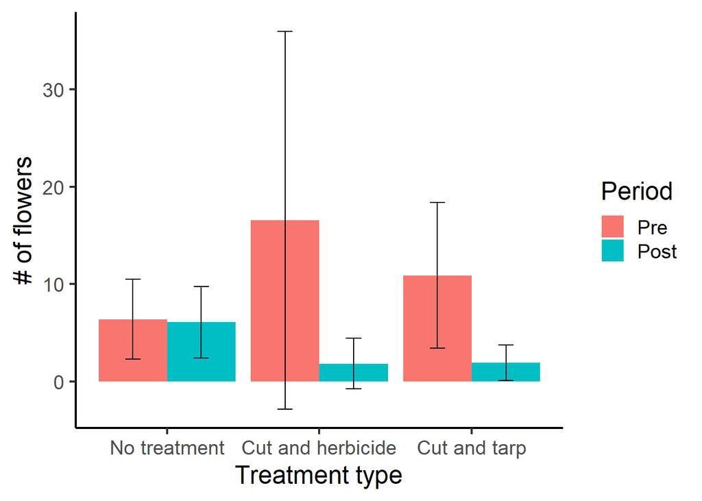

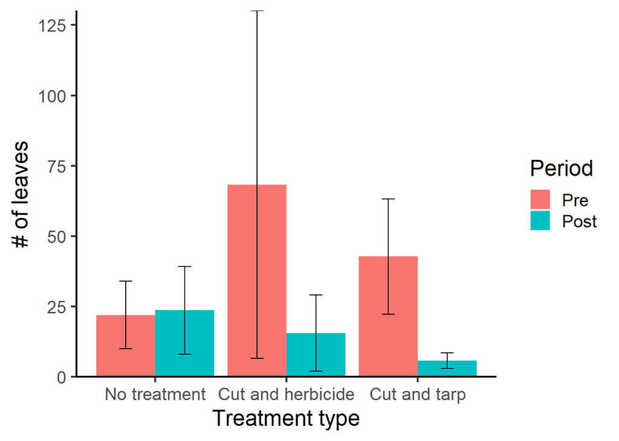

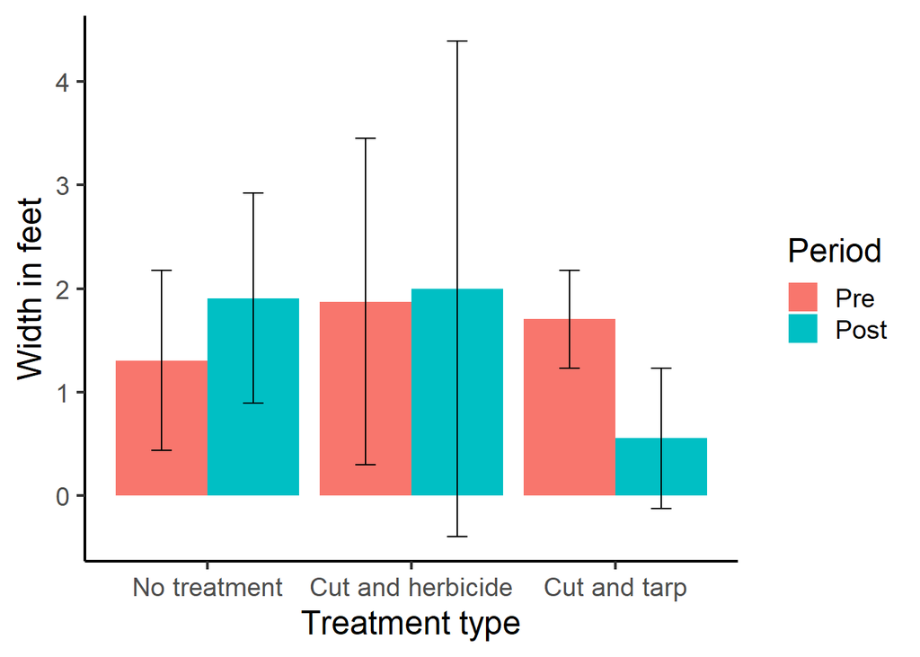

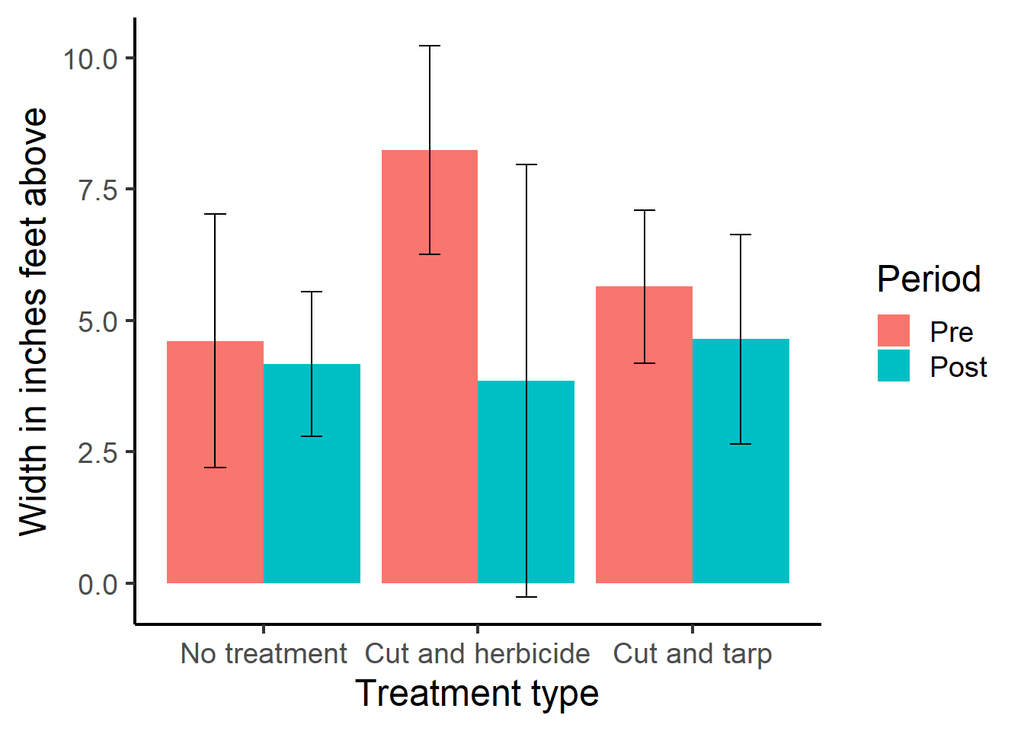

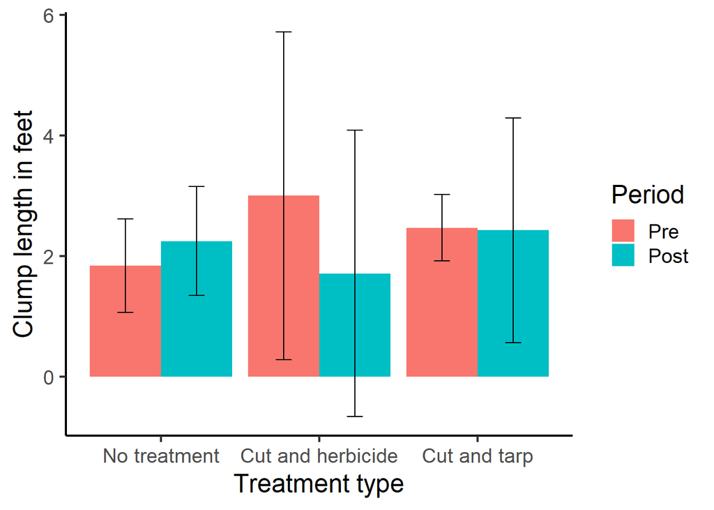

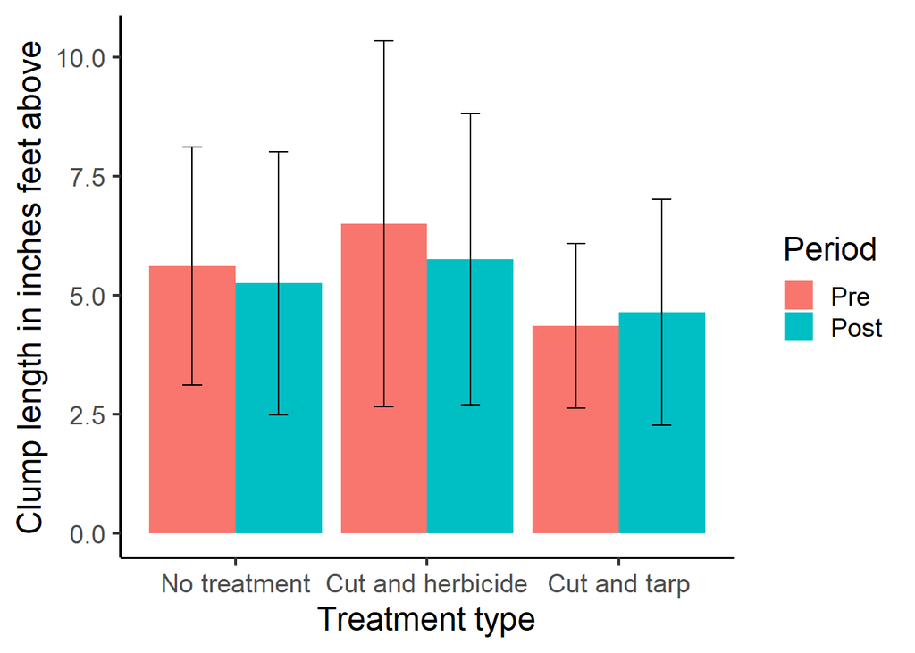

This does make it clear that there may be some true effects on the # of flowering stalks - but the amount of variability in those estimates between plots appears to dampen the statistical significance of this effect. Regardless, I think it is safe to say that Cut and Tarp is about as effective as Cut and Herbicide, but appears to do some things that Cut and Herbicide treatments do not (namely, changing width).